# Categorical Data Analysis

Chi-square, Fisher’s, and Risk Measures

## The Clinical Problem

The district surveillance officer constructs a 2×2 table for biryani exposure:

|  | Ate Biryani | Did Not | Total |
| --- | --- | --- | --- |
| **Ill** | 65 | 15 | 80 |
| **Well** | 30 | 50 | 80 |
| **Total** | 95 | 65 | 160 |

**Questions:** Is biryani associated with illness? How strong is the association? What’s the clinical impact?

## The 2×2 Contingency Table

The fundamental building block of categorical data analysis:

|  | **Disease** | **No Disease** | **Total** |
| --- | --- | --- | --- |
| **Exposed** | a | b | a + b |
| **Not Exposed** | c | d | c + d |
| **Total** | a + c | b + d | N |

From this single table we can derive:

- **Tests:** Chi-square, Fisher’s exact
- **Association:** RR, OR
- **Impact:** ARR, NNT, AR, PAR

## Chi-square Test of Independence

**H₀:** Exposure and disease are independent (no association)

**H₁:** Exposure and disease are associated

**In words:** For each cell, take (Observed − Expected)², divide by Expected, sum across all cells.

$$\chi^2 = \sum \frac{(\text{Observed} - \text{Expected})^2}{\text{Expected}}$$

For a 2×2 table, the **cross-product shortcut:**

$$\chi^2 = \frac{N(ad - bc)^2}{(a+b)(c+d)(a+c)(b+d)}, \quad df = 1$$

**Expected frequency:** $E_{ij} = \frac{\text{Row Total} \times \text{Column Total}}{\text{Grand Total}}$

## Worked Example: Biryani Outbreak

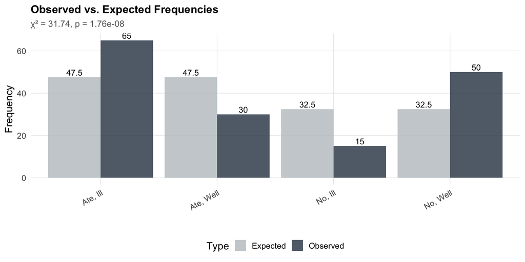

**Reject H₀** — biryani exposure and illness are significantly associated.

## When Chi-square Fails: Fisher’s Exact Test

**Use Fisher’s exact test when:**

- Any expected cell frequency < 5
- Total sample size N < 20–30
- Rare disease or rare exposure

**Example:** Leptospirosis cluster after flooding in Alappuzha, Kerala (N = 25):

|  | Leptospirosis | Healthy |
| --- | --- | --- |
| Waded in floodwater | 8 | 2 |
| Did not wade | 3 | 12 |

Fisher’s p = 0.0051, OR = 13.77

## McNemar’s Test: Paired Categorical Data

**Same subjects, before–after** → only **discordant pairs** matter

**Example:** TB knowledge in 100 contacts, Patna — before and after health education

|  | After: Correct | After: Incorrect |
| --- | --- | --- |
| **Before: Correct** | 55 | **5** |
| **Before: Incorrect** | **25** | 15 |

$$\chi^2_{\text{McNemar}} = \frac{(b - c)^2}{b + c} = \frac{(5 - 25)^2}{30} = 13.33, \quad p < 0.001$$

Knowledge significantly improved after education. The 55 + 15 concordant pairs are **ignored**.

## Measures of Association: Overview

| Measure | In Words | Cell Notation | Use |
| --- | --- | --- | --- |
| Relative Risk (RR) | Risk in Exposed ÷ Risk in Unexposed | a/(a+b) ÷ c/(c+d) | Cohort |
| Odds Ratio (OR) | Odds in Exposed ÷ Odds in Unexposed | ad / bc | Case-control |
| ARR | Risk in Control − Risk in Treatment | Rc − Rt | Trials |
| RRR | ARR ÷ Risk in Control | ARR / Rc | Trials |
| NNT | 1 ÷ ARR (treat how many to save one?) | 1 / ARR | Clinical |
| NNH | 1 ÷ Absolute Risk of Harm | 1 / ARH | Safety |
| AR | Risk in Exposed − Risk in Unexposed | Re − Ru | Individual |
| PAR | Fraction of population disease due to exposure | Pe(RR−1) / [Pe(RR−1)+1] | Public health |

## Relative Risk (RR)

**In words:** Risk of disease in Exposed ÷ Risk of disease in Unexposed

$$RR = \frac{\text{Incidence in Exposed}}{\text{Incidence in Unexposed}} = \frac{a/(a+b)}{c/(c+d)}$$

**Outbreak example:**

- Risk in exposed (biryani): 0.684 (68.4%)
- Risk in unexposed: 0.231 (23.1%)
- **RR = 2.96** — biryani eaters were 3× more likely to fall ill

**Key:** RR can only be calculated from **cohort studies** where you follow exposed and unexposed groups forward.

## Odds Ratio (OR)

**In words:** Odds of disease in Exposed ÷ Odds of disease in Unexposed

$$OR = \frac{\text{Odds in Exposed}}{\text{Odds in Unexposed}} = \frac{ad}{bc} \quad \text{(cross-product ratio)}$$

- **OR = 7.22**

**Why not just use RR?**

In **case-control studies**, you cannot calculate incidence → cannot get RR → must use OR.

**The critical question:** When does OR ≈ RR?

## OR ≈ RR: The Rare Disease Assumption

$$OR \approx RR \text{ when disease prevalence < 5–10%}$$

[figure not shown]

## 95% Confidence Interval for OR

$$OR_{95\%CI} = OR \times e^{\pm\, 1.96 \times SE(\ln OR)}$$

where $SE(\ln OR) = \sqrt{1/a + 1/b + 1/c + 1/d}$

**Outbreak result:** OR = 7.22 (95% CI: 3.51 – 14.86)

**Interpretation rule:**

- CI includes 1.0 → **not significant** (p > 0.05)
- CI excludes 1.0 → **significant** (p < 0.05)

## ARR, RRR, and NNT

**TB vaccine trial in Varanasi:** Vaccinated 5/500 (1%); Unvaccinated 20/500 (4%)

**ARR** (how much does treatment lower absolute risk?):

$$ARR = \text{Risk in Control} - \text{Risk in Treatment} = 4\% - 1\% = 3\%$$

**RRR** (what fraction of baseline risk is removed?):

$$RRR = \frac{ARR}{\text{Risk in Control}} = \frac{3\%}{4\%} = 75\%$$

**NNT** (how many to treat to prevent one case?):

$$NNT = \frac{1}{ARR} = \frac{1}{0.03} \approx 33$$

**Clinical meaning:** Vaccinate 33 people to prevent one case of TB.

**Warning**

RRR (75%) sounds impressive; ARR (3%) gives the true clinical picture.

## NNT and NNH: The Full Picture

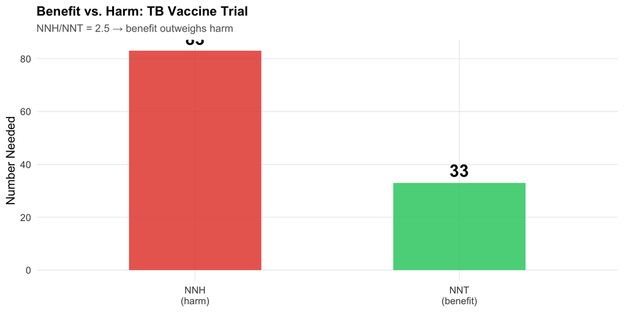

**Therapeutic index** = NNH / NNT = 83 / 33 = 2.5 → Benefit outweighs harm → Recommend vaccination

## Attributable Risk (AR) and Population Attributable Risk (PAR)

**AR** — excess risk from exposure (individual level)

$$AR = \text{Risk in Exposed} - \text{Risk in Unexposed}$$

*“How much extra disease does the exposure cause?”*

. . .

**Smoking example:**

AR = 8% − 1% = 7%

AR% = 7/8 = **87.5%** of lung cancer in smokers is attributable to smoking

**PAR** — population-level impact (depends on both RR *and* exposure prevalence)

$$PAR\% = \frac{P_e(RR - 1)}{P_e(RR - 1) + 1} \times 100$$

*“If we eliminated this exposure, what fraction of ALL disease would disappear?”*

. . .

If 40% smoke, RR = 8:

PAR% = **73.7%** of all lung cancer could be prevented by eliminating smoking

## Decision Guide: Choosing the Right Test

| Scenario | Test / Measure |
| --- | --- |
| 2 independent groups, expected freq ≥ 5 | Chi-square test |
| 2 independent groups, expected freq < 5 | Fisher's exact test |
| Paired / before–after | McNemar's test |
| Cohort study → risk measure | Relative Risk (RR) |
| Case-control study → association measure | Odds Ratio (OR) |
| Clinical impact of treatment | ARR, RRR, NNT, NNH |

## Common Pitfalls

### Avoid

- Chi-square with expected freq < 5
- Interpreting OR as RR at high prevalence
- Claiming causation from chi-square alone
- Forgetting to report 95% CI for OR/RR
- Confusing ARR (absolute) with RRR (relative)

### Remember

- Fisher’s exact test for small samples
- OR ≈ RR only when disease is rare (< 5–10%)
- McNemar’s for paired categorical data
- NNT = 1/ARR, not 1/RRR
- CI excluding 1.0 → statistically significant

## Key Takeaways

1. **Chi-square** tests association between two categorical variables (check expected freq ≥ 5)
2. **Fisher’s exact** for small samples; **McNemar’s** for paired before–after data
3. **RR** from cohort studies; **OR** from case-control studies
4. **OR ≈ RR** only when disease is rare (< 5–10% prevalence)
5. **ARR** gives the true clinical impact; **RRR** can be misleading
6. **NNT = 1/ARR** — lower is better; compare NNT to NNH for net benefit
7. **AR** for individual counselling; **PAR** for public health policy
8. Always report **95% CI** — if it excludes 1.0, the result is significant